# Vouch-her!? I HUDly know her!

Liz Lawler and Micah Villarreal

5/6/2018

# Introduction

For our term project, we examined relationships found within two datasets.  
1. PHA-“program type”-level data about the state of subsidized housing in the United States in 2014, courtesy of the Department of Housing and Urban Development (HUD). Though HUD engages in several different housing assistance program types, we limited our analysis to Housing Choice Voucher (HCV) programs. https://www.huduser.gov/portal/datasets/assthsg.html  
For more information on what each variable in this dataset: https://www.huduser.gov/portal/datasets/pictures/dictionary_2017.pdf  
2. PHA-person-level data about the compensation (salary, bonus and total compensation) of the top three paid employees at every public housing authority in the United States. We limited this data to the top paid individual at each PHA. https://www.hud.gov/program_offices/public_indian_housing/programs/pha_executive_compensation  
We constructed a PHA-level dataset with programmatic, geographic and compensation information about every HCV program in the United States, as well as rich demographic data about each program’s clients.

## Households Receiving Subsidized Housing by Region

We first decided to look at the number of households by census region, and display the porportion of female heads of household to male heads of household. As you can see, across all regions, the majority of households receiving subsidized housing are headed by females. We were surprised to see how many households were headed by females *without* children. Further exploration could include examining the age distribution within these households; one hypothesis might be that the regions with households headed by females with no children also have a higher percentage of elderly people in public housing.

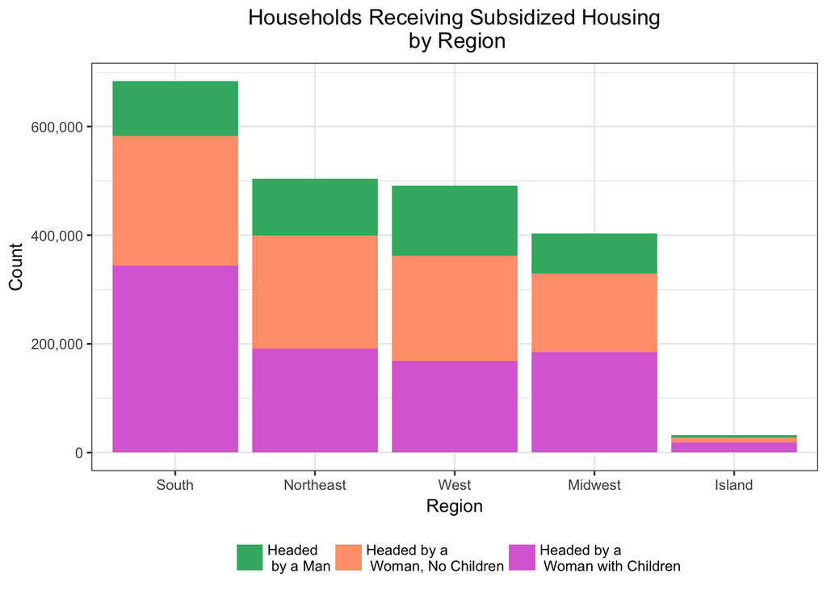

## Total Compensation of Public Housing Authority Executives

### Distribution

Next, we looked at the distribution of the maximum Total Compensation.

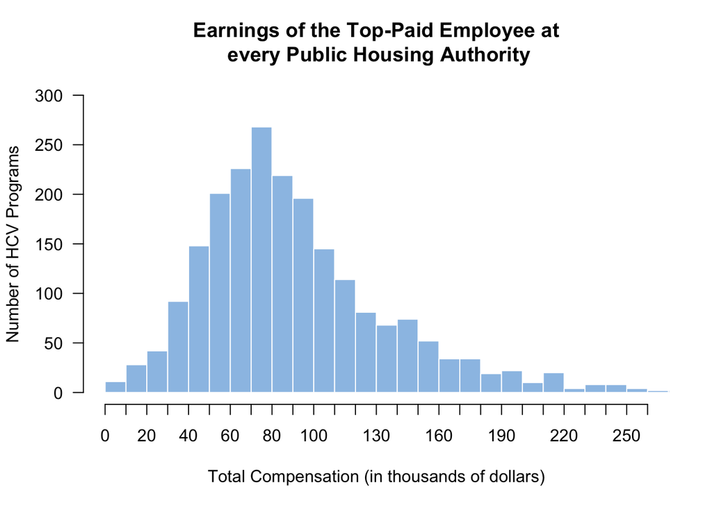

### Relationships and Comparisons

We then looked at the relationship between total compensation and poverty areas. We performed a permutation test on compensation of highest paid employee by whether the program was located in a high poverty area or not.

- Observed difference in means: [1] 6064.802
- Permutation test p-value: [1] 0.0013

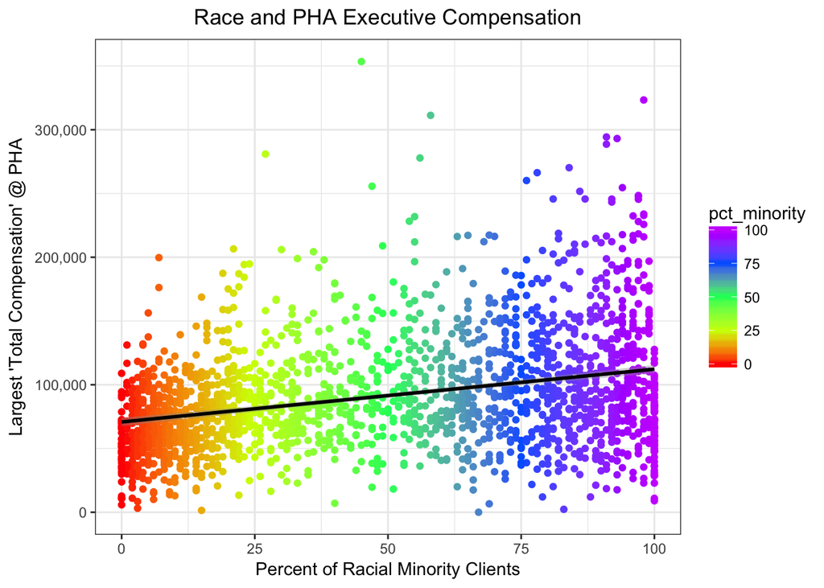

We did not expect that for each additonal percentage point minority in the HCV Program, executive compensation increases by $414, and it’s statistically significant (per our linear regression)! We expected these things to be unrelated.  
**Total comp and tenant income**  
Positive correlation between Total Executive Compensation and Tenant Income: [1] 0.261203

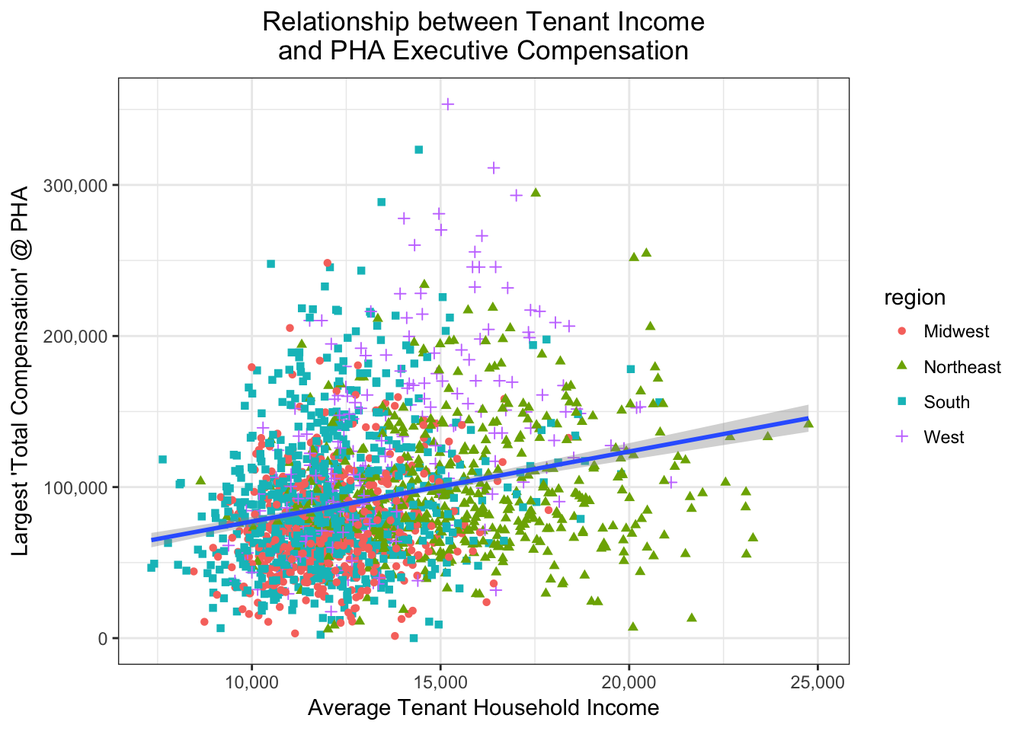

As we expected, total compensation of PHA executives increases with tenant income.

## Average Rent Burden of Public Housing Authority Tenants

### Distribution

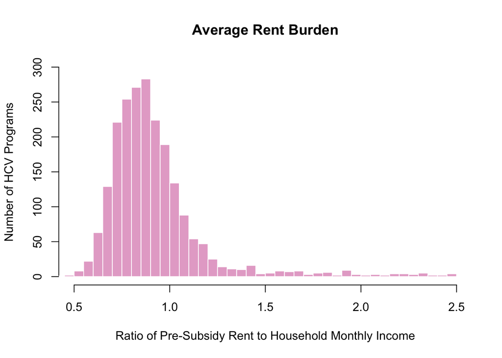

### Geographical visualization

We then overlayed rent burden on a map of the United States to better visualize the spread. We did this in two ways: 1) overlaying the mean rent burden by state (shown here) and 2) overlaying each individual PHA’s rent burden across the US (shown in original R script).

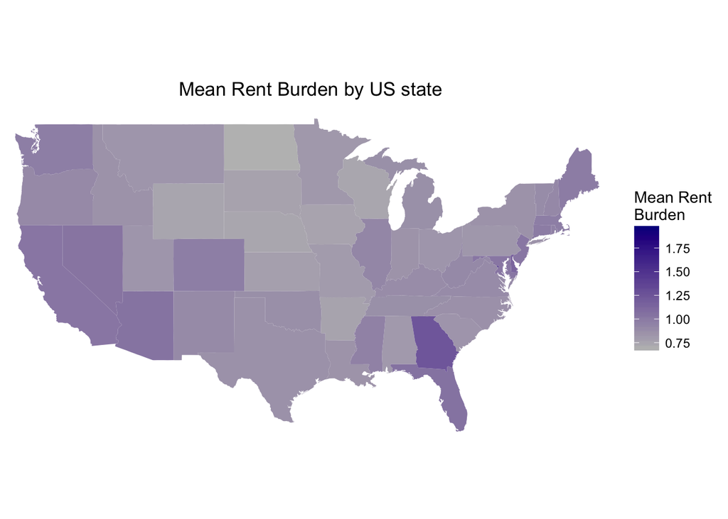

We found it interesting that Georgia has a high mean rent burden! And you can see that the West Coast and Northeast states also have a relatively high mean rent burden (not as high as Georgia). The Midwest appears to have a lower mean rent burden, but this could also be due to the low data density in that area (as you can see on the other map produced in the Rscript).

## Average Months Waiting for a Home

### Distribution

Next, we looked at the distribution of “average months waiting”.

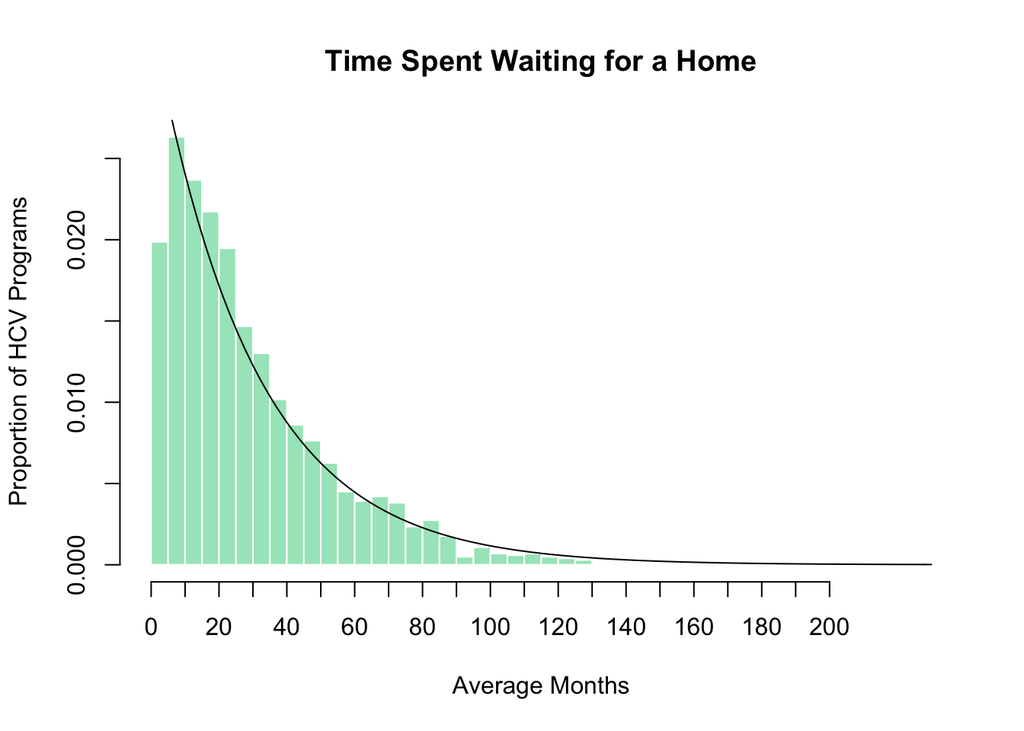

It makes sense that an exponential curve fits “number of months waiting” very well. This curve arises when examining the length of time between events in Poisson processes.

### Relationship with poverty area

Next, we used two methods to examine the relationship between “average months waiting” and whether or not the respective area was considered a “poverty area” (Census Bureau designates census tracts with a poverty rate >=20% as “poverty areas”).

First, we created a contingency table of “months waiting” categories crossed with “poverty areas”" (Census Bureau designates census tracts with a poverty rate >=20% as “poverty areas”).

Observed Distribution of Average Months Waiting per Poor and Non-poor Areas

| Average Months Waiting | Poverty Area FALSE | Poverty Area TRUE |
| --- | --- | --- |
| 0 to < 6 mo. | 109 | 94 |
| 6 to < 12 mo. | 148 | 177 |
| 12 to < 18 mo. | 118 | 155 |
| 18 to < 24 mo. | 112 | 148 |
| 24 to < 3 mo. | 75 | 125 |
| 30 to < 36 mo. | 69 | 88 |
| 36+ mo. | 312 | 313 |

Expected Distribution of Average Months Waiting per Poor and Non-poor Areas

| Average Months Waiting | Poverty Area FALSE | Poverty Area TRUE |
| --- | --- | --- |
| 0 to < 6 mo. | 93.69995 | 109.30005 |
| 6 to < 12 mo. | 150.01224 | 174.98776 |
| 12 to < 18 mo. | 126.01028 | 146.98972 |
| 18 to < 24 mo. | 120.00979 | 139.99021 |
| 24 to < 3 mo. | 92.31522 | 107.68478 |
| 30 to < 36 mo. | 72.46745 | 84.53255 |
| 36+ mo. | 288.48507 | 336.51493 |

Chi-square test: chi^2(6) = 16.53, p = .011

- Observed difference in means: [1] -1.779025
- Permutation test p-value: [1] 0.9454705